# HW 1

Glebus Alexandr

2023-10-31

## 1. Загрузите датасет insurance_cost.csv (лежит в папке домашнего задания). Это данные по базовым показателям здоровья индивида и сумме, которую страховая компания заплатила за его лечение в год. Обычно эти данные используют, чтобы потренироваться в предсказании того, как определённые характеристики индивида повышают траты страховой компании (и, соответственно, должны быть заложены в цену страховки).

```r
insurance_cost <- readr::read_csv('insurance_cost.csv', show_col_types = FALSE)
insurance_cost %>% glimpse()
```

```
## Rows: 1,338
## Columns: 7
## $ age      <dbl> 19, 18, 28, 33, 32, 31, 46, 37, 37, 60, 25, 62, 23, 56, 27, 1…
## $ sex      <chr> "female", "male", "male", "male", "male", "female", "female",…
## $ bmi      <dbl> 27.900, 33.770, 33.000, 22.705, 28.880, 25.740, 33.440, 27.74…
## $ children <dbl> 0, 1, 3, 0, 0, 0, 1, 3, 2, 0, 0, 0, 0, 0, 0, 1, 1, 0, 0, 0, 0…
## $ smoker   <chr> "yes", "no", "no", "no", "no", "no", "no", "no", "no", "no", …
## $ region   <chr> "southwest", "southeast", "southeast", "northwest", "northwes…
## $ charges  <dbl> 16884.924, 1725.552, 4449.462, 21984.471, 3866.855, 3756.622,…
```

```r
library(skimr)
skim(insurance_cost)
```

Data summary

| Name | insurance_cost |
| --- | --- |
| Number of rows | 1338 |
| Number of columns | 7 |
| _______________________ |  |
| Column type frequency: |  |
| character | 3 |
| numeric | 4 |
| ________________________ |  |
| Group variables | None |

**Variable type: character**

| skim_variable | n_missing | complete_rate | min | max | empty | n_unique | whitespace |
| --- | --- | --- | --- | --- | --- | --- | --- |
| sex | 0 | 1 | 4 | 6 | 0 | 2 | 0 |
| smoker | 0 | 1 | 2 | 3 | 0 | 2 | 0 |
| region | 0 | 1 | 9 | 9 | 0 | 4 | 0 |

**Variable type: numeric**

| skim_variable | n_missing | complete_rate | mean | sd | p0 | p25 | p50 | p75 | p100 | hist |
| --- | --- | --- | --- | --- | --- | --- | --- | --- | --- | --- |
| age | 0 | 1 | 39.21 | 14.05 | 18.00 | 27.00 | 39.00 | 51.00 | 64.00 | ▇▅▅▆▆ |
| bmi | 0 | 1 | 30.66 | 6.10 | 15.96 | 26.30 | 30.40 | 34.69 | 53.13 | ▂▇▇▂▁ |
| children | 0 | 1 | 1.09 | 1.21 | 0.00 | 0.00 | 1.00 | 2.00 | 5.00 | ▇▂▂▁▁ |
| charges | 0 | 1 | 13270.42 | 12110.01 | 1121.87 | 4740.29 | 9382.03 | 16639.91 | 63770.43 | ▇▂▁▁▁ |

```r
library(GGally)
```

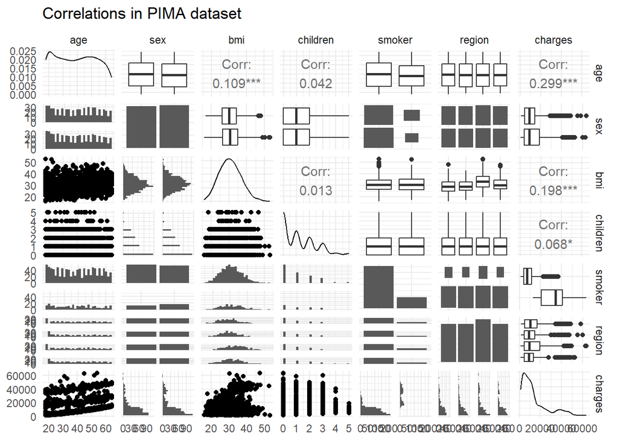

```r
ggpairs(insurance_cost,
        title = 'Correlations in PIMA dataset',progress = F) +
    theme_minimal() +
    scale_fill_manual(values = c('#69b3a2')) +
    scale_colour_manual(values = c('#69b3a2'))
```

## 2. Выведите гистограммы всех нумерических переменных.

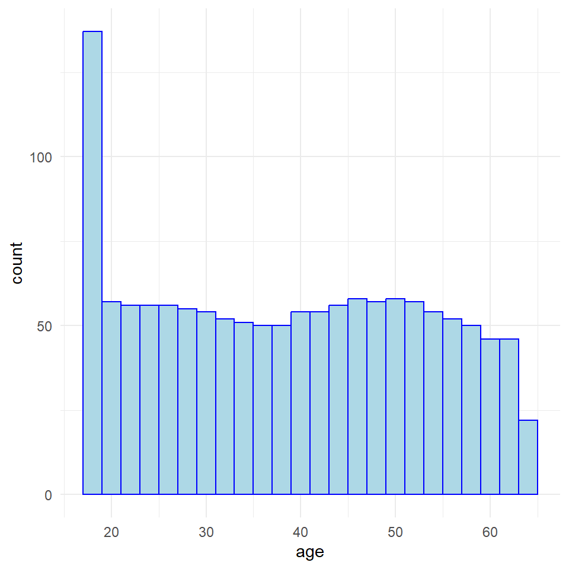

```r
insurance_cost %>% ggplot() +
  aes(age) +
  geom_histogram(binwidth = 2, color="blue", fill="lightblue") +
  theme_minimal()
```

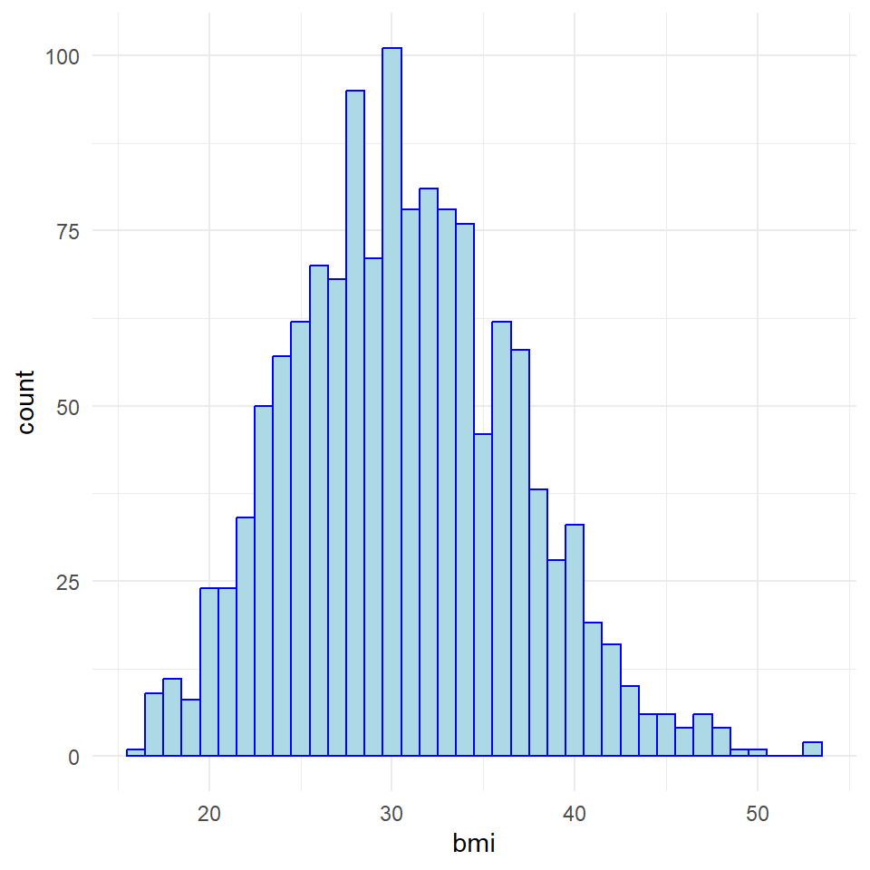

```r
insurance_cost %>% ggplot() +
  aes(bmi) +
  geom_histogram(binwidth = 1, color="blue", fill="lightblue") +
  theme_minimal()
```

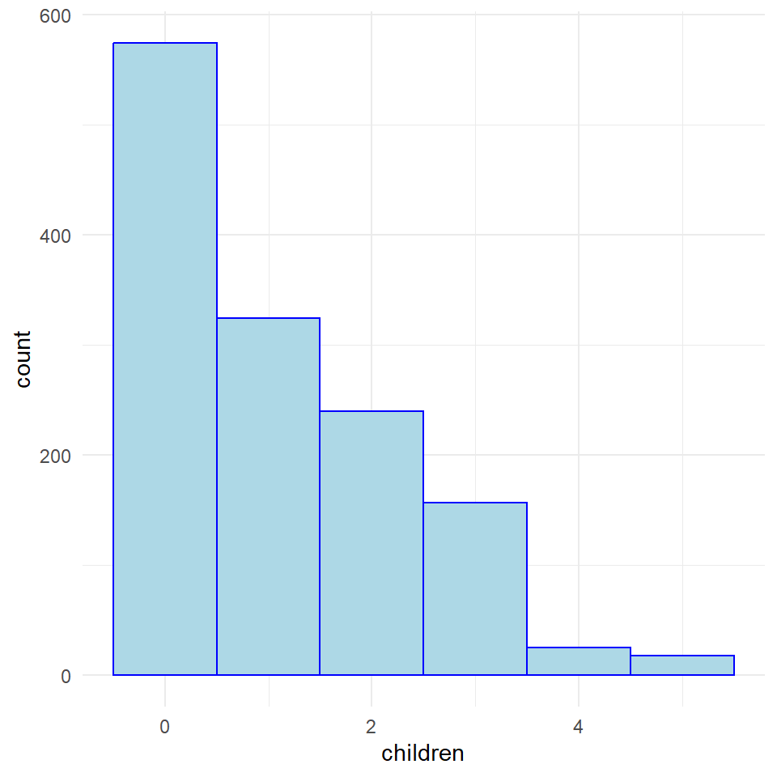

```r
insurance_cost %>% ggplot() +
  aes(children) +
  geom_histogram(bins = 6, color="blue", fill="lightblue") +
  theme_minimal()
```

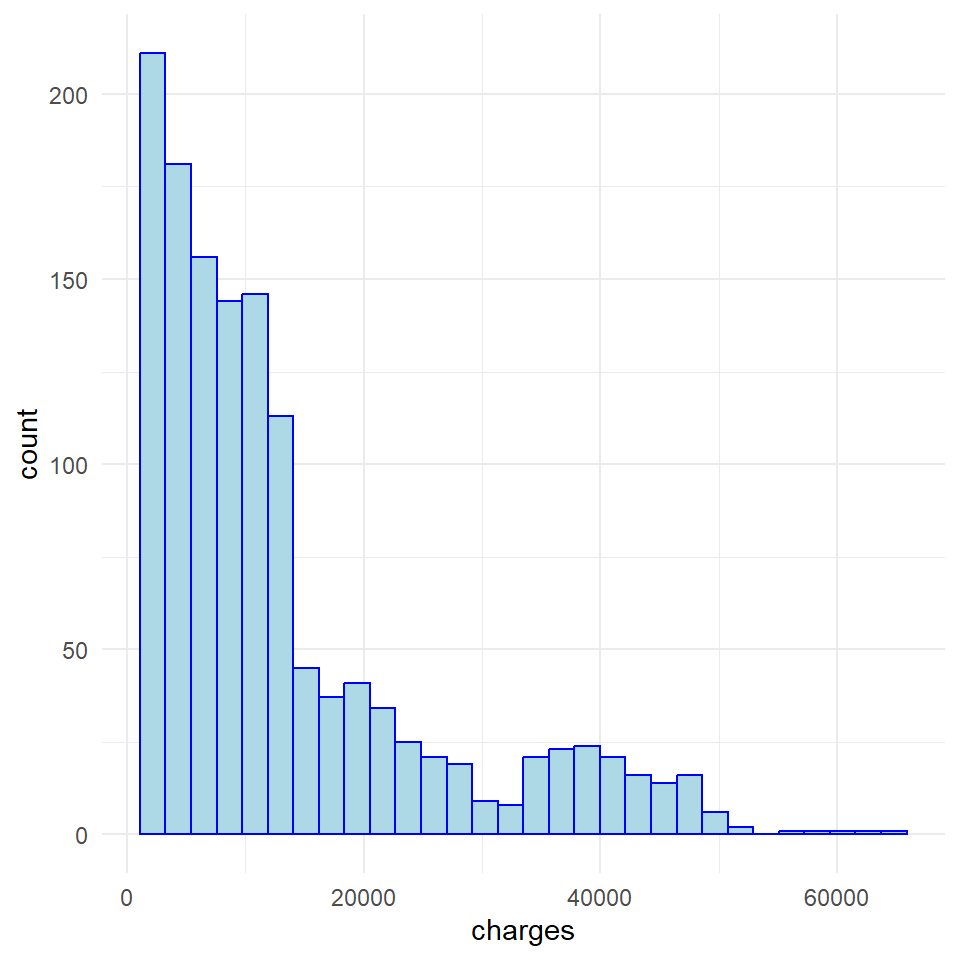

```r
insurance_cost %>% ggplot() +
  aes(charges) +
  geom_histogram(bins = 30, color="blue", fill="lightblue") +
  theme_minimal()
```

## 3. Нарисуйте график плотности по колонке charges. Отметьте вертикальные линии средней и медианы на графике. Раскрасьте текст и линии средней и медианы разными цветами. Добавьте текстовые пояснения, значения средней и медианы.Подберите тему для графика. Назовите оси.

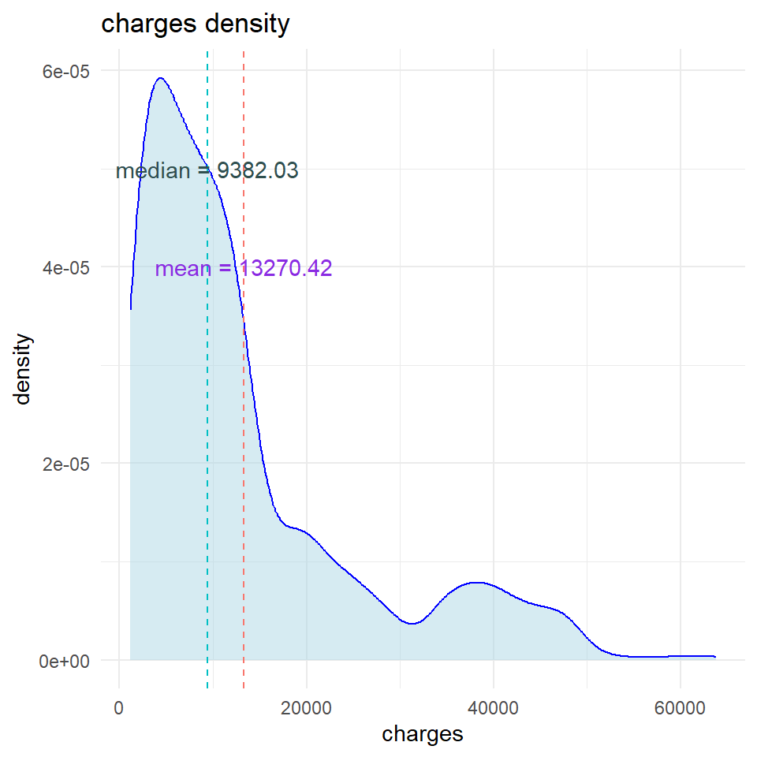

```r
fig <- insurance_cost %>% ggplot() +
  aes(charges) +
  geom_density(fill = "lightblue", color = "blue", alpha = 0.5) +
  geom_vline(aes(xintercept = mean(charges), color = "blueviolet"), linetype = "dashed") +
  geom_vline(aes(xintercept = median(charges), color = "darkslategray"), linetype = "dashed") +
  annotate("text", x = mean(insurance_cost$charges), y = 0.00004, label = paste("mean =", round(mean(insurance_cost$charges), 2)), color = "blueviolet") +
  annotate("text", x = median(insurance_cost$charges), y = 0.00005, label = paste("median =", round(median(insurance_cost$charges), 2)), color = "darkslategray") +
  labs(x = "charges", y = "density") +
  ggtitle("charges density") +
  theme_minimal() +
  theme(legend.position = "none")
fig
```

## 4. Сделайте три box_plot по отношению переменных charges и (1) sex (2) smoker (3) region. Подберите тему для графика. Назовите оси.

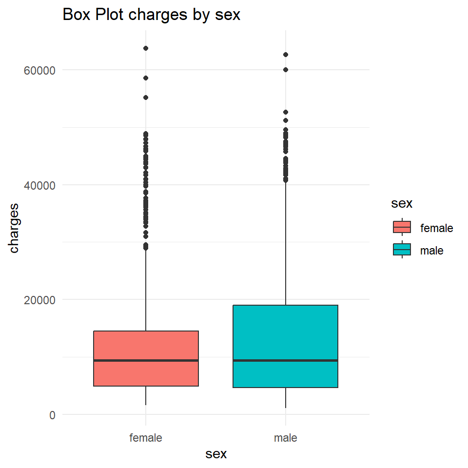

```r
fig1 <- insurance_cost %>%
  ggplot(aes(x = sex, y = charges, fill = sex)) +
  geom_boxplot() +
  ggtitle("Box Plot charges by sex") +
  theme_minimal()
fig1
```

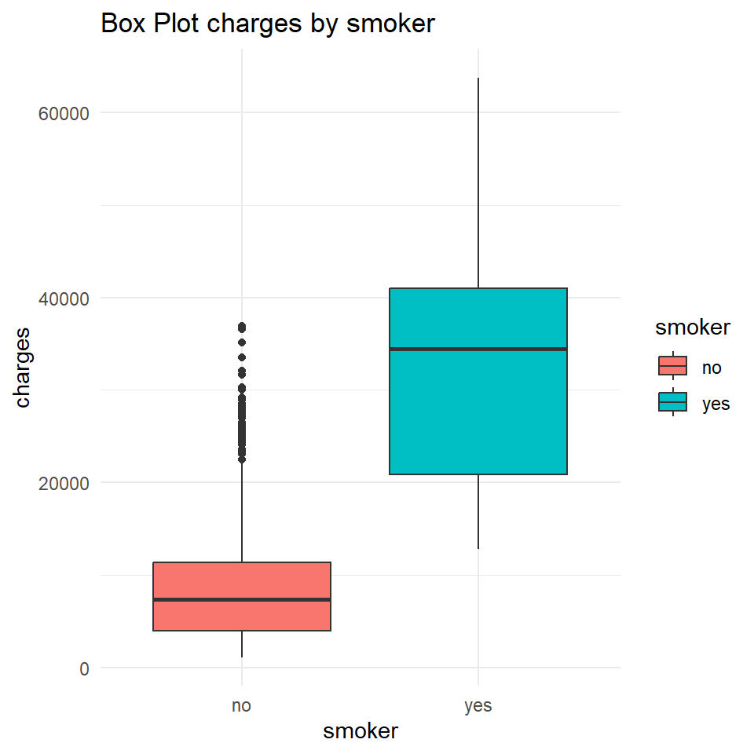

```r
fig2 <- insurance_cost %>%
  ggplot(aes(x = smoker, y = charges, fill = smoker)) +
  geom_boxplot() +
  ggtitle("Box Plot charges by smoker") +
  theme_minimal()
fig2
```

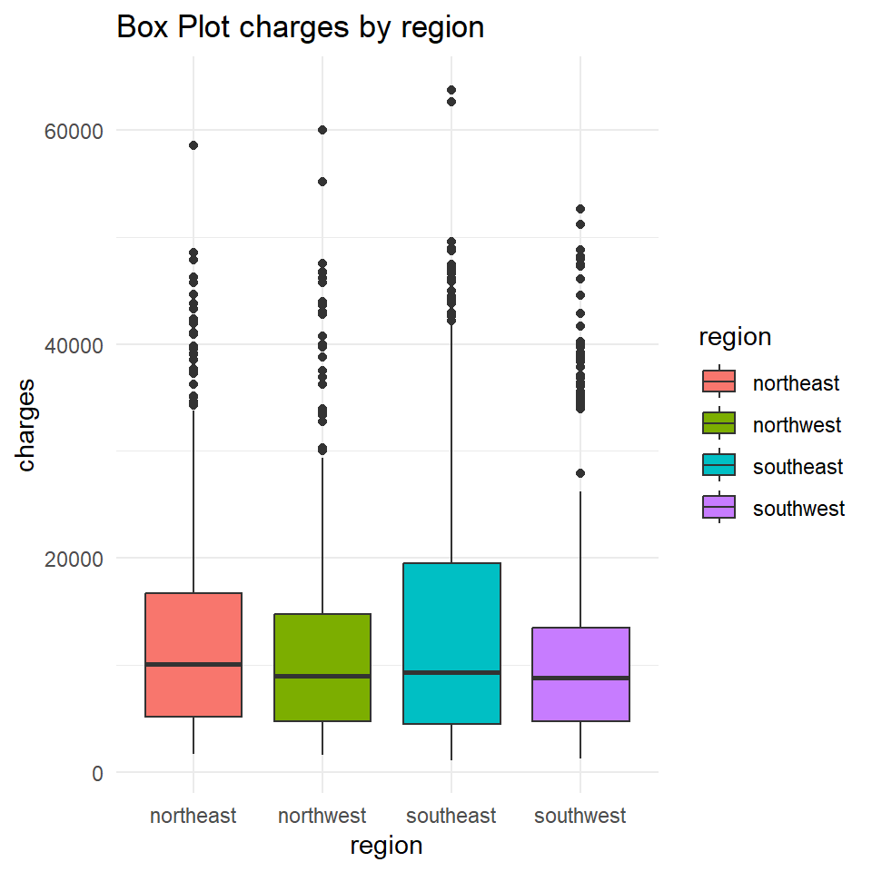

```r
fig3 <- insurance_cost %>%
  ggplot(aes(x = region, y = charges, fill = region)) +
  geom_boxplot() +
  ggtitle("Box Plot charges by region") +
  theme_minimal()
fig3
```

## 5.Объедините графики из заданий 3 и 4 в один так, чтобы сверху шёл один график из задания 3, а под ним 3 графика из задания 4. Сделайте общее название для графика.

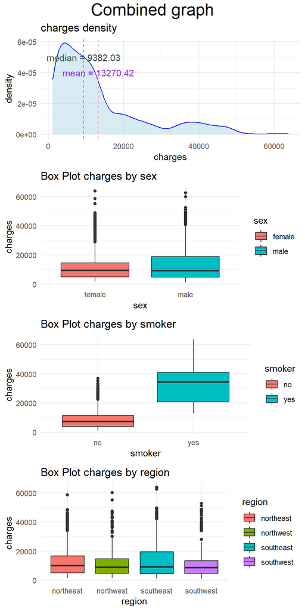

```r
library(ggpubr)
fig5 <- ggarrange(fig, fig1, fig2, fig3, nrow = 4)
annotate_figure(fig5, top = text_grob("Combined graph", size=20))
```

## 6. Сделайте фасет графика из задания 3 по колонке region.

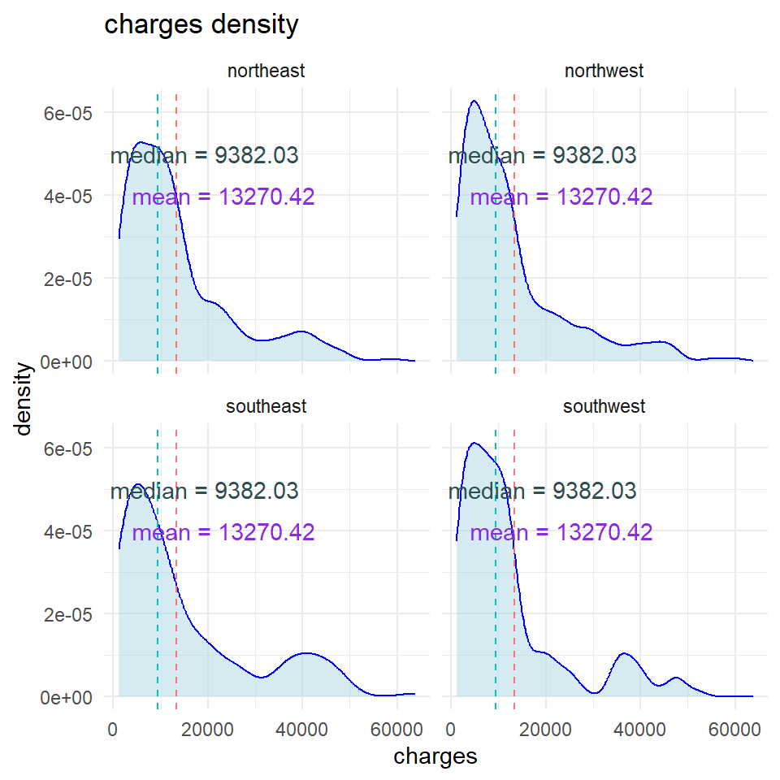

```r
insurance_cost %>% ggplot() +
  aes(charges) +
  geom_density(fill = "lightblue", color = "blue", alpha = 0.5) +
  geom_vline(aes(xintercept = mean(charges), color = "blueviolet"), linetype = "dashed") +
  geom_vline(aes(xintercept = median(charges), color = "darkslategray"), linetype = "dashed") +
  annotate("text", x = mean(insurance_cost$charges) + 10000, y = 0.00004, label = paste("mean =", round(mean(insurance_cost$charges), 2)), color = "blueviolet") +
  annotate("text", x = median(insurance_cost$charges) + 10000, y = 0.00005, label = paste("median =", round(median(insurance_cost$charges), 2)), color = "darkslategray") +
  labs(x = "charges", y = "density") +
  ggtitle("charges density") +
  theme_minimal() +
  facet_wrap(~ region, ncol = 2) +
  theme(legend.position = "none")
```

## 7. Постройте scatter plot отношения переменных age и charges. Добавьте названия осей, название графика и тему. Сделайте так, чтобы числа по оси Х отображались 14 шрифтом.

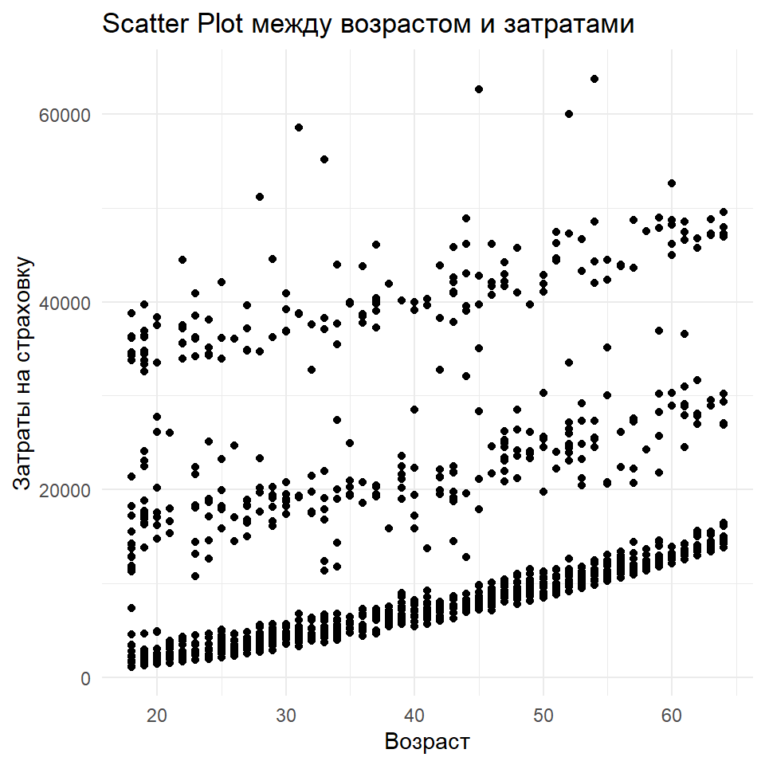

```r
fig6 <- insurance_cost %>% ggplot() +
  aes(x = age, y = charges) +
  geom_point() +
  labs(x = "Возраст", y = "Затраты на страховку", title = "Scatter Plot между возрастом и затратами") +
  theme(axis.text.x = element_text(size = 14)) +
  theme_minimal()
fig6
```

## 8. Проведите линию тренда для предыдущего графика.

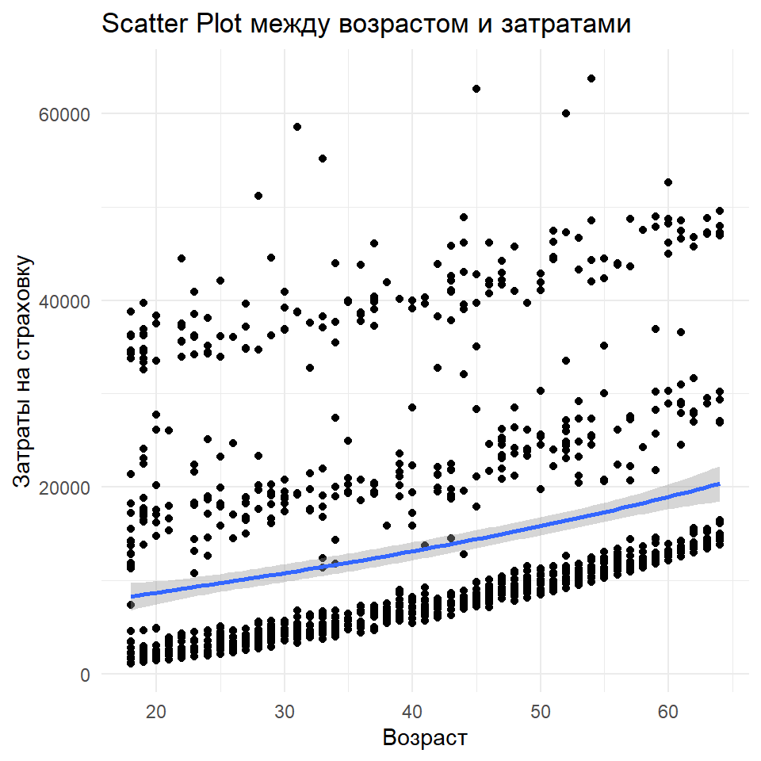

```r
fig6 +
  geom_smooth()
```

## 9. Сделайте разбивку предыдущего графика по колонке smokers (у вас должно получится две линии тренда для курящих и нет).

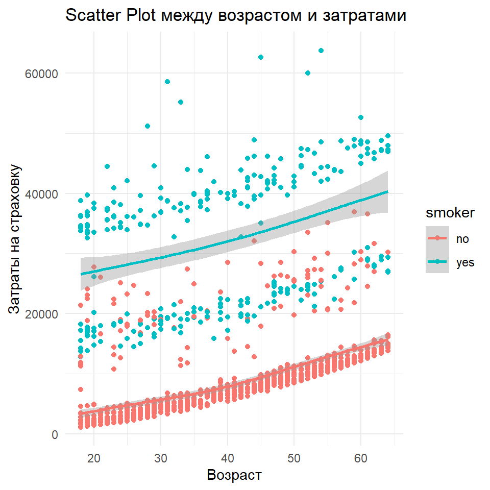

```r
fig6 +
  geom_smooth() +
  aes(col = smoker)
```

## 10. Сделайте график из заданий 7-9, но вместо переменной age используйте переменную bmi.

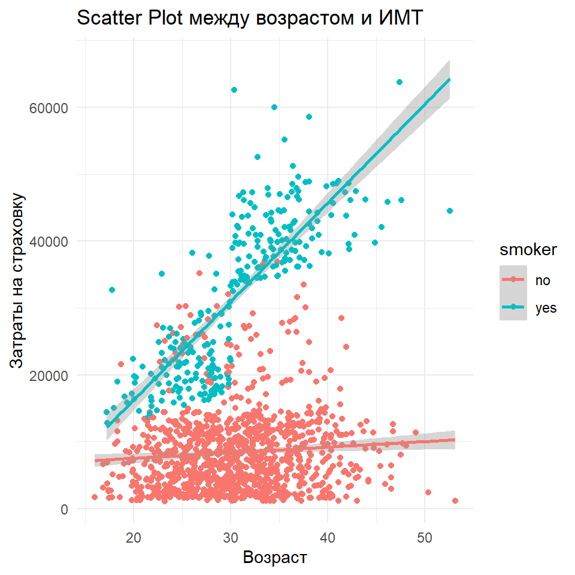

```r
insurance_cost %>% ggplot() +
  aes(x = bmi, y = charges, col = smoker) +
  geom_point() +
  labs(x = "Возраст", y = "Затраты на страховку", title = "Scatter Plot между возрастом и ИМТ") +
  theme(axis.text.x = element_text(size = 14)) +
  geom_smooth(method = lm) +
  theme_minimal()
```

## 14. (это задание засчитывается за два) Приблизительно повторите график.

```r
insurance_cost_group <- insurance_cost %>%
  mutate(age_group = case_when(
    age < 21 ~ "Under 21",
    age >= 21 & age <= 34 ~ "age: 21-34",
    age >= 35 & age < 49 ~ "age: 35-49",
    age >= 50 ~ "age: 50+")) %>%
  mutate(age_group = as.factor(age_group)) %>%
  filter(age_group %in% c("age: 21-34", "age: 35-49", "age: 50+"))
```

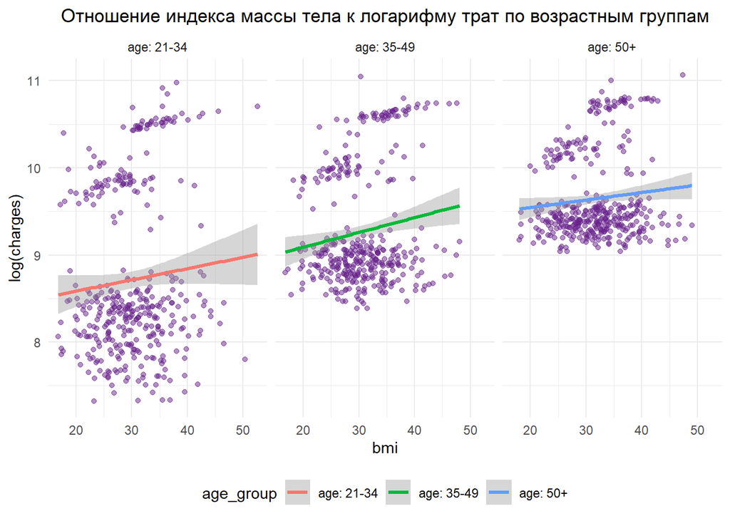

```r
insurance_cost_group %>%  ggplot() +
  aes(x = bmi, y = log(charges)) +
  geom_point(color = "darkorchid4", alpha = 0.5) +
  labs(title = "Отношение индекса массы тела к логарифму трат по возрастным группам") +
  theme(axis.text.x = element_text(size = 14)) +
  geom_smooth(method = lm,  aes(color = age_group), size = 1.1) +
  facet_wrap(~ age_group) +
  theme_minimal() +
  theme(
    plot.title = element_text(hjust = 0.5),
    legend.position = "bottom"
  )
```